# Boston on a Budget

STT303 Project 2 · Real Airbnb data · Teams of 2–3

JOPE — Osvaldo Perez-Eslava

## 1. Cleaning, validation and study scope

Explain string/factor/date operations, missingness, sequential exclusions and validation. State why this is a filtered snapshot rather than a random sample of all Boston lodging.

**The string, factor, and date operations were used to help clean the entirety of the data set that shares a common format between entries with similar values. Missingness focus on entries that are unavailable to view or obtain. Simply because it doesn’t exist or an error in retrieving the data, they data with the missing entry is still valuable, thus it must be accounted for or at least preserved for operation. Sequential exclusions work with missingness as when looking for one exclusive data point, the entries with that data missing can be excluded with case by case iteration. This could later be used to iterate each desired data entry to the point that every entry in the set is complete. Validation is used to check and confirm that the entries have no missing data points for plotting, data analysis, and predictions for adding new entries. This is a filtered snapshot of the Boston lodging for the data given is only a set number of listings released on the 19th and 20th of September, 2026, ignoring any past lodgings from that timeframe.**

```r
cleaning_audit
```

```
## # A tibble: 1 × 12
##   `raw_rows <- nrow(listings_raw)` duplicate_rows <- ra…¹ clean_rows <- nrow(l…²
##                              <int>                  <int>                  <int>
## 1                             4368                      0                   4368
## # ℹ abbreviated names:
## #   ¹`duplicate_rows <- raw_rows - nrow(distinct(listings_raw))`,
## #   ²`clean_rows <- nrow(listings_clean)`
## # ℹ 9 more variables:
## #   `missing_price <- sum(is.na(listings_clean$price_usd))` <int>,
## #   `missing_capacity <- sum(is.na(listings_clean$accommodates))` <int>,
## #   `missing_minimum_nights <- ...` <int>, …
```

## 2. Exploring the budget listings

Discuss shape, mean/median, unusual values, room-type differences and review status. Explain the $500 cutoff and why reviews do not directly measure demand.

```r
 room_summary
```

```
## # A tibble: 2 × 5
##   room_type           n mean_price median_price sd_price
##   <fct>           <int>      <dbl>        <dbl>    <dbl>
## 1 private room      515       179.         164.     87.3
## 2 entire home/apt  1152       306.         296.     90.5
```

```r
 review_summary
```

```
## # A tibble: 3 × 3
##   review_status      n mean_price
##   <fct>          <int>      <dbl>
## 1 recent          1522       267.
## 2 older             64       235.
## 3 no review date    81       289.
```

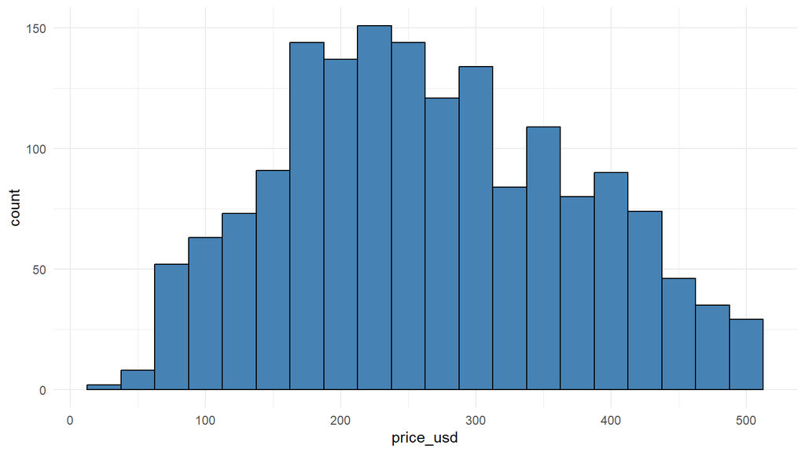

```r
 plot_price
```

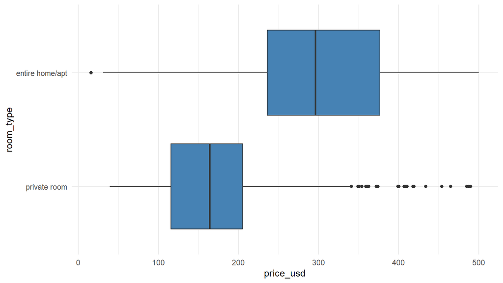

```r
 plot_room
```

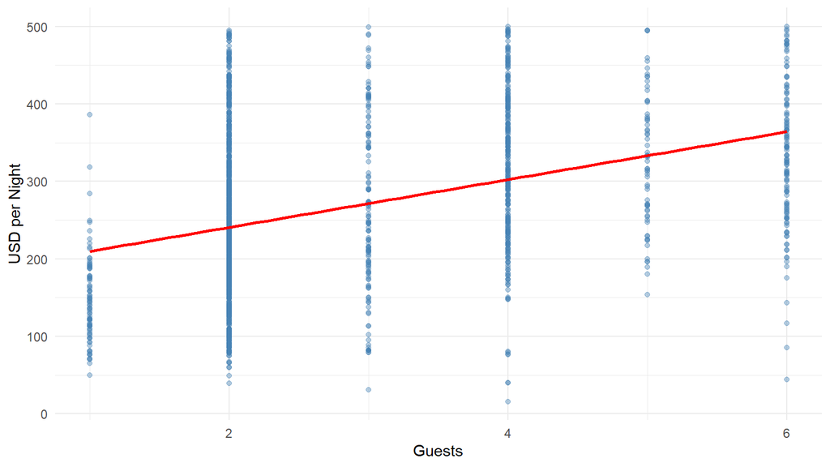

```r
 plot_capacity
```

## 3. Guest capacity and listed price

Write the equation and interpret slope, intercept, the four-guest prediction and the first residual. Discuss residual structure and causality.

**Y = 178.87 + 30.89X For the slope, as the number of guests the room can accommodate increases by one, the price per night in USD increases by a value of 30.89. The intercept is the typical starting value of the room where a hypothetical room that can accommodate 0 guests is valued at a price of 178.87 USD per night. With those two in mind, the predicted price for a 4 person accommodation would be 302.43. This value is a prediction and not the true value for such accommodation as the only variable that was accounted for the estimation is the number of guests.**

```r
 capacity_cor
```

```
## [1] 0.3858344
```

```r
 capacity_terms
```

```
## # A tibble: 2 × 2
##   term         estimate
##   <chr>           <dbl>
## 1 (Intercept)     179.
## 2 accommodates     30.9
```

```r
 capacity_predictions
```

```
##   accommodates predicted_price
## 1            2        240.6522
## 2            4        302.4330
## 3            6        364.2139
```

```r
 head(capacity_augmented, 1)
```

```
## # A tibble: 1 × 8
##   price_usd accommodates .fitted .resid     .hat .sigma  .cooksd .std.resid
##       <dbl>        <dbl>   <dbl>  <dbl>    <dbl>  <dbl>    <dbl>      <dbl>
## 1       131            2    241.  -110. 0.000840   99.0 0.000517      -1.11
```

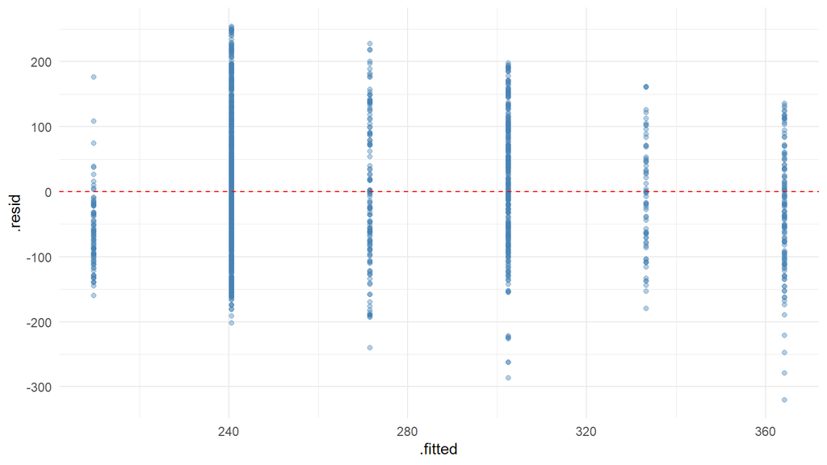

```r
 plot_residual
```

## 4. Private rooms versus entire places

Interpret the reference mean and difference. Demonstrate equality to group means and explain why this comparison is unadjusted.

```r
 room_terms
```

```
## # A tibble: 2 × 2
##   term                     estimate
##   <chr>                       <dbl>
## 1 (Intercept)                  179.
## 2 room_typeentire home/apt     128.
```

```r
 room_predictions
```

```
##         room_type predicted_price
## 1    private room        178.5223
## 2 entire home/apt        306.3163
```

## 5. Sampling variability

Compare centers and spreads, individual-price SD and sample-mean SD. Explain the seed, sampling design and limited population.

```r
 population_mean
```

```
## [1] 266.8359
```

```r
 sampling_summary
```

```
## # A tibble: 2 × 3
##   sample_size mean_of_means sd_of_means
##         <dbl>         <dbl>       <dbl>
## 1          20          267.        24.2
## 2          80          267.        11.8
```

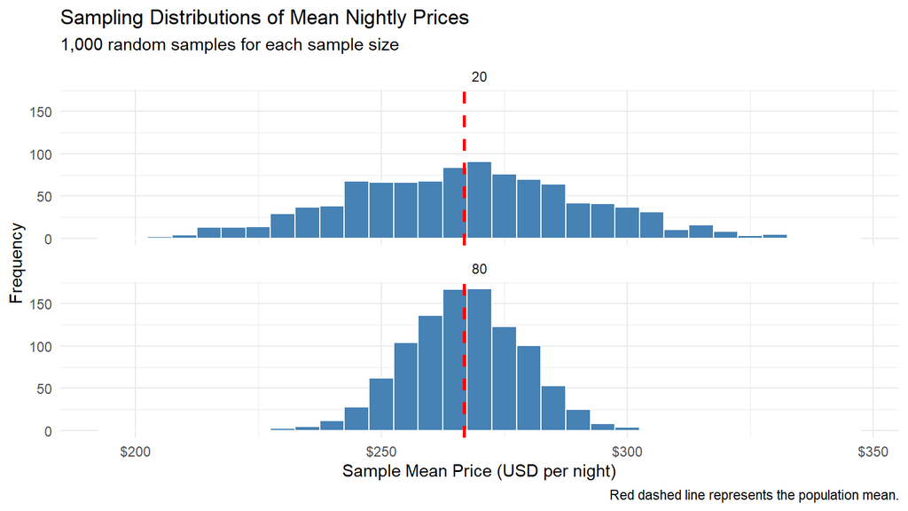

```r
 plot_sampling
```

## 6. Traveler briefing

Give two evidence-based takeaways and two limitations. Address reported prices versus actual booking costs.

## Team contributions and verification

Team ID: **JOPE**  
Members (2 or 3): **Osvaldo Perez-Eslava, Myself, I**  
Designated submitter: **Osvaldo Perez-Eslava**

Complete one row per member; remove the third row for a two-person team. Each member must contribute to analysis, interpretation, and peer review.

| Member | R analysis contributed | Written interpretation contributed | Work reviewed and one concrete finding/check |
| --- | --- | --- | --- |
| Osvaldo | All | All | All |
| Jose | Very Little | Very Little | None |
| Myself | Nothing | Nada | Zilch |

- Final integrator: **Osvaldo Perez-Eslava**
- Fresh-session verifier (a different member): **Osvaldo Perez-Eslava**
- Verification date and result of running analysis.R and knitting the report: **Osvaldo Perez-Eslava**
- Confirmation that all members reviewed and approved the complete submission: **Osvaldo Perez-Eslava**

This section does not count toward the 900–1,300-word report limit.

## Data attribution

Data from [Inside Airbnb](https://insideairbnb.com/get-the-data/), Boston snapshot September 19, 2026, used under [CC BY 4.0](https://creativecommons.org/licenses/by/4.0/). Adapted for STT303 by selecting nine columns; all source rows and values retained. Analysis filters are documented above. See data/PROVENANCE.txt for the pinned source.

## Analysis code appendix

```r
# STT303 Project 2: Boston on a Budget
# Team ID: Osvaldo Perez-Eslava
# Members (2 or 3):
# Section leads draft; another member reviews. Submit one integrated script.
# Run from the project root. Do not edit the supplied CSV or use absolute paths.
library(tidyverse)
library(lubridate)
library(broom)

# 1. Create listings_raw, listings_clean, analysis_data and cleaning_audit.
# Import ALL columns as character (IDs exceed exact double-integer precision).
# Check/remove exact duplicates, normalize labels, and parse numbers/dates.
# Add days_since_review and review_status; missing review dates remain valid.
# Apply the exact sequential study-scope rules from the instructions.
# Hint: as.numeric(snapshot_date - last_review) gives a difference in days.
listings_raw <- read.csv(here::here("data", "boston_listings_raw.csv"), colClasses = 'character') |> distinct()
listings_clean <- tibble(
  #Complete ID maintained
  listing_id = listings_raw$id,
  #Parses Listing date in YYYY-MM-DD
  snapshot_date = listings_raw$last_scraped |>
    ymd(),
  #Squishes the neighborhood names to remove surrounding whitespace and reduce whitespace between words
  neighborhood = listings_raw$neighbourhood_cleansed |>
    str_squish(),
  #Squishes the listings types, turns the letters into lowercase, and as an unordered factor
  room_type = listings_raw$room_type |>
    str_squish() |>
    str_to_lower() |>
    factor(
      levels = c(
        "private room",
        "entire home/apt",
        "shared room",
        "hotel room"
      ),
      ordered = FALSE
    ),
  #Parses the capacity into ints
  accommodates = listings_raw$accommodates |>
    as.numeric(),
  #Parses the price into ints
  price_usd = listings_raw$price |>
    str_extract("\\d+\\.\\d+") |>
    as.numeric(),
  #Parses the nights into ints
  minimum_nights = listings_raw$minimum_nights |>
    as.numeric(),
  #Parses review date in YYYY-MM-DD
  last_review = listings_raw$last_review |>
    ymd(),
  #Parses the number of reviews into ints
  number_of_reviews = listings_raw$number_of_reviews |>
    as.numeric()
)

listings_clean <- listings_clean |>
  mutate(
    accommodates = if_else(accommodates <= 0, NA, accommodates),
    price_usd = if_else(price_usd <= 0, NA, price_usd),
    minimum_nights = if_else(minimum_nights <= 0, NA, minimum_nights),
    days_since_review = as.numeric(snapshot_date - last_review),
    review_status = case_when(
      is.na(last_review) ~ "no review date",
      days_since_review >= 0 & days_since_review <= 180 ~ "recent",
      days_since_review > 180 ~ "older",
      .default = NA
    ) |>
      factor(
        levels = c(
          "recent",
          "older",
          "no review date"
        ),
        ordered = FALSE
      )
  )
###
#This sections is to check for any future review dates
future_reviews <- listings_clean |>
  filter(days_since_review < 0) |>
  select(listing_id, snapshot_date, last_review, days_since_review)

future_reviews

nrow(future_reviews)

complete_data <- listings_clean |>
  filter(
    !is.na(price_usd),
    !is.na(accommodates),
    !is.na(minimum_nights),
    !is.na(room_type),
    !is.na(snapshot_date))

room_data <- complete_data |>
  filter(room_type == "private room" | room_type == "entire home/apt")

capacity_data <- room_data |>
  filter(accommodates >= 1, accommodates <= 6)

stay_data <- capacity_data |>
  filter(minimum_nights >= 1, minimum_nights <= 7)

analysis_data <- stay_data |>
  filter(price_usd > 0, price_usd <= 500) |>
  mutate(
    room_type = droplevels(room_type),
    room_type = relevel(room_type, ref = "private room")
  ) |>
  arrange(as.character(listing_id))

cleaning_audit <- tibble(
  raw_rows <- nrow(listings_raw),
  duplicate_rows <- raw_rows - nrow(distinct(listings_raw)),
  clean_rows <- nrow(listings_clean),
  missing_price <- sum(is.na(listings_clean$price_usd)),
  missing_capacity <- sum(is.na(listings_clean$accommodates)),
  missing_minimum_nights <- sum(is.na(listings_clean$minimum_nights)),
  missing_review_date <- sum(is.na(listings_clean$last_review)),
  complete_rows <- nrow(complete_data),
  room_rows <- nrow(room_data),
  capacity_rows <- nrow(capacity_data),
  stay_rows <- nrow(stay_data),
  analysis_rows <- nrow(analysis_data)
)
nrow(analysis_data)

n_distinct(analysis_data$listing_id)

sum(duplicated(analysis_data$listing_id))

range(analysis_data$snapshot_date, na.rm = TRUE)

range(analysis_data$last_review, na.rm = TRUE)

unique(analysis_data$room_type)

unique(analysis_data$review_status)

levels(analysis_data$room_type)

levels(analysis_data$review_status)

sum(analysis_data$days_since_review < 0, na.rm = TRUE)

summary(analysis_data$days_since_review)

sum(is.na(analysis_data$days_since_review))

summary(analysis_data$price_usd)
summary(analysis_data$accommodates)
summary(analysis_data$minimum_nights)

table(analysis_data$room_type)
table(analysis_data$review_status, useNA = "always")

glimpse(analysis_data)

# 2. Create room_summary, review_summary, plot_price, plot_room, plot_capacity.

room_summary <- analysis_data |>
  group_by(room_type) |>
  summarise(
    n = n(),
    mean_price = mean(price_usd),
    median_price = median(price_usd),
    sd_price = sd(price_usd),
    .groups = "drop"
  )

review_summary <- analysis_data |>
  group_by(review_status) |>
  summarise(
    n = n(),
    mean_price = mean(price_usd),
    .groups = "drop"
  )

plot_price <- ggplot(analysis_data, aes(x = price_usd)) +
  geom_histogram(
    binwidth = 25,
    fill = "steelblue",
    color = "black"
  ) +
  theme_minimal()

plot_room <- ggplot(analysis_data, aes(x = room_type, y = price_usd)) +
  geom_boxplot(
    fill = "steelblue"
  ) +
  coord_flip() +
  theme_minimal()

plot_capacity <- ggplot(
  analysis_data,
  aes(x = accommodates, y = price_usd)
) +
  geom_point(
    alpha = 0.4,
    color = "steelblue"
  ) +
  labs(
    x = "Guests",
    y = "USD per Night"
  ) +
  geom_smooth(
    method = "lm",
    formula = y ~ x,
    se = FALSE,
    color = "red"
  ) +
  theme_minimal()


# 3. Create capacity_cor, capacity_model, capacity_terms, capacity_augmented,
# capacity_predictions, plot_residual.
capacity_cor <- cor(
  analysis_data$accommodates,
  analysis_data$price_usd,
  use = "complete.obs"
)

capacity_model <- lm(
  price_usd ~ accommodates,
  data = analysis_data
)

capacity_terms <- broom::tidy(capacity_model) |>
  select(term, estimate)

capacity_augmented <- broom::augment(capacity_model)

capacity_predictions <- data.frame(
  accommodates = c(2, 4, 6)
) |>
  mutate(
    predicted_price = predict(
      capacity_model,
      newdata = data.frame(
        accommodates = accommodates
      )
    )
  )


plot_residual <- ggplot(
  capacity_augmented,
  aes(x = .fitted, y = .resid)
) +
  geom_point(
    alpha = 0.4,
    color = "steelblue"
  ) +
  geom_hline(
    yintercept = 0,
    linetype = "dashed",
    color = "red"
  ) +
  theme_minimal()


# 4. Create room_model, room_terms and room_predictions.
# Reference group: private room. Verify predictions equal group means.
room_model <- lm(
  price_usd ~ room_type,
  data = analysis_data
)

summary(room_model)

analysis_data$room_type <- relevel(
  analysis_data$room_type,
  ref = "private room"
)

room_terms <- broom::tidy(room_model) |>
  select(term, estimate)

room_predictions <- data.frame(
  room_type = factor(
    c("private room", "entire home/apt"),
    levels = c("private room", "entire home/apt")
  )
) |>
  mutate(
    predicted_price = predict(
      room_model,
      newdata = data.frame(
        room_type = room_type
      )
    )
  )

room_comparison <- room_predictions |>
  left_join(
    room_summary |>
      select(room_type, mean_price),
    by = "room_type"
  ) |>
  mutate(
    difference = predicted_price - mean_price
  )




# 5. Create population_mean, sampling_means, sampling_summary, plot_sampling.
# set.seed(30322); all 1,000 n=20 draws first, then all 1,000 n=80 draws.
# Hint: replicate(1000, mean(sample(x, size=..., replace=FALSE)))
population_mean <- mean(analysis_data$price_usd)

set.seed(30322)

x <- analysis_data$price_usd

# Generate 1,000 sample means with sample size 20
means_20 <- replicate(
  1000,
  mean(sample(x, size = 20, replace = FALSE))
)

# Generate 1,000 sample means with sample size 80
means_80 <- replicate(
  1000,
  mean(sample(x, size = 80, replace = FALSE))
)

sampling_means <- tibble(
  sample_size = c(
    rep(20, 1000),
    rep(80, 1000)
  ),
  mean_price = c(
    means_20,
    means_80
  )
)

sampling_summary <- sampling_means |>
  group_by(sample_size) |>
  summarise(
    mean_of_means = mean(mean_price),
    sd_of_means = sd(mean_price),
    .groups = "drop"
  )
plot_sampling <- ggplot(
  sampling_means,
  aes(x = mean_price)
) +
  geom_histogram(
    binwidth = 5,
    fill = "steelblue",
    color = "white"
  ) +
  geom_vline(
    xintercept = population_mean,
    color = "red",
    linetype = "dashed",
    linewidth = 1
  ) +
  facet_wrap(
    ~ sample_size,
    ncol = 1
  ) +
  labs(
    title = "Sampling Distributions of Mean Nightly Prices",
    subtitle = "1,000 random samples for each sample size",
    x = "Sample Mean Price (USD per night)",
    y = "Frequency",
    caption = "Red dashed line represents the population mean."
  ) +
  scale_x_continuous(
    labels = scales::label_dollar()
  ) +
  theme_minimal()



# Write interpretation and team verification in project2.Rmd.
```